# Analysis of Long Term Unemployment Rate Percent From 1990 to 2017

## Plotting Few More Graphs

- I am going to plot graphs for Albania and Zimbabwe
- Albania is first country in the dataset & Zimbabwe is the last country in the dataset
- Albania has considerable amount of NaN, while Zimbabwe has only one value filled
- I am going to plot graphs for Albania & Zimbabwe, and fill NaN with Various Interpolation techniques to choose the one that is apt for this dataset

```python
sample_zimbabwe = df_melt[df_melt['country'].isin(["Albania", "Zimbabwe"])]
```

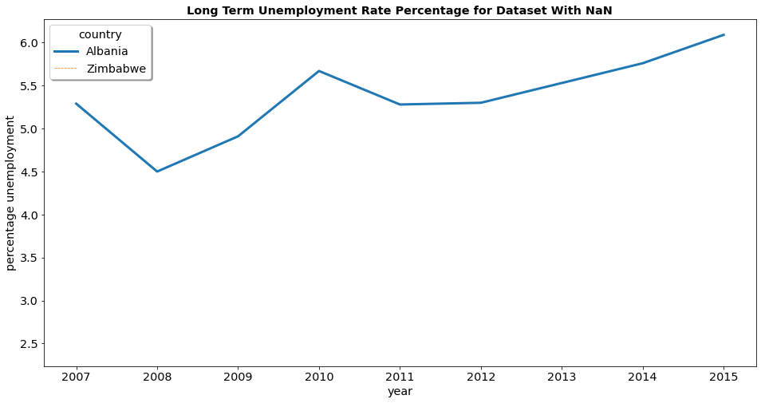

```python
plt.figure(figsize = (16, 8))
sb.lineplot(x = 'year', y='percent_unemployment', data=sample_zimbabwe, hue='country', style='country',
            size='country')
plt.xticks(fontsize='x-large')
plt.yticks(fontsize='x-large')
plt.legend(title='country', title_fontsize='x-large', fontsize='x-large',loc='best',
          frameon=True, fancybox=True, shadow=True)
plt.title("Long Term Unemployment Rate Percentage for Dataset With NaN", fontdict={'fontsize': 'x-large', 'fontweight': 'bold'})
plt.xlabel("year", fontsize='x-large')
plt.ylabel("percentage unemployment", fontsize='x-large');
```

```python
sample_zimbabwe_linear = df_melt_linear[df_melt_linear['country'].isin(["Albania", "Zimbabwe"])]
```

```python
sample_with_linear.head()
```

|  | country | year | percent_unemployment |
| --- | --- | --- | --- |
| 90 | Russia | 1990 | 0.525048 |
| 115 | United States | 1990 | 0.278000 |
| 212 | Russia | 1991 | 0.529762 |
| 237 | United States | 1991 | 0.436000 |
| 334 | Russia | 1992 | 0.631000 |

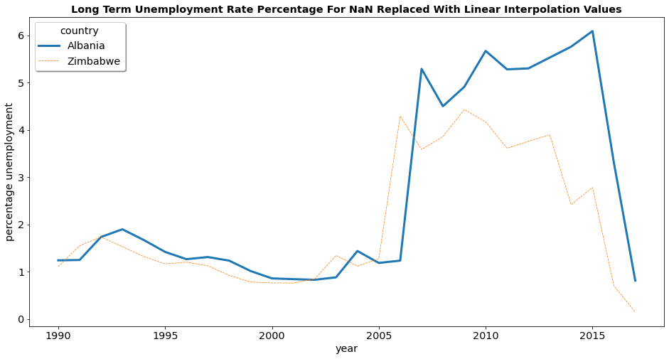

```python
plt.figure(figsize = (16, 8))
sb.lineplot(x = 'year', y='percent_unemployment', data=sample_zimbabwe_linear, hue='country', style='country',
            size='country')
plt.xticks(fontsize='x-large')
plt.yticks(fontsize='x-large')
plt.legend(title='country', title_fontsize='x-large', fontsize='x-large',loc='best',
          frameon=True, fancybox=True, shadow=True)
plt.title("Long Term Unemployment Rate Percentage For NaN Replaced With Linear Interpolation Values", fontdict={'fontsize': 'x-large', 'fontweight': 'bold'})
plt.xlabel("year", fontsize='x-large')
plt.ylabel("percentage unemployment", fontsize='x-large');
```

```python
sample_zimbabwe_polinomial = df_melt_polinomial[df_melt_polinomial['country'].isin(["Albania", "Zimbabwe"])]
```

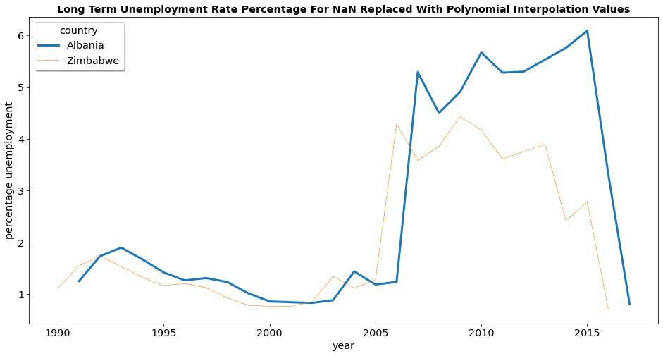

```python
plt.figure(figsize = (16, 8))
sb.lineplot(x = 'year', y='percent_unemployment', data=sample_zimbabwe_polinomial, hue='country', style='country',
            size='country')
plt.xticks(fontsize='x-large')
plt.yticks(fontsize='x-large')
plt.legend(title='country', title_fontsize='x-large', fontsize='x-large',loc='best',
          frameon=True, fancybox=True, shadow=True)
plt.title("Long Term Unemployment Rate Percentage For NaN Replaced With Polynomial Interpolation Values", fontdict={'fontsize': 'x-large', 'fontweight': 'bold'})
plt.xlabel("year", fontsize='x-large')
plt.ylabel("percentage unemployment", fontsize='x-large');
```

```python
sample_zimbabwe_polinomial.head()
```

|  | country | year | percent_unemployment |
| --- | --- | --- | --- |
| 0 | Albania | 1990 | NaN |
| 121 | Zimbabwe | 1990 | 1.109000 |
| 122 | Albania | 1991 | 1.247500 |
| 243 | Zimbabwe | 1991 | 1.548000 |
| 244 | Albania | 1992 | 1.733333 |

```python
sample_zimbabwe_spline = df_melt_spline[df_melt_spline['country'].isin(["Albania", "Zimbabwe"])]
```

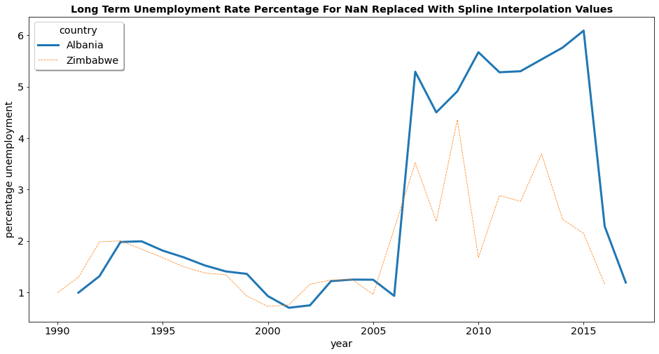

```python
plt.figure(figsize = (16, 8))
sb.lineplot(x = 'year', y='percent_unemployment', data=sample_zimbabwe_spline, hue='country', style='country',
            size='country')
plt.xticks(fontsize='x-large')
plt.yticks(fontsize='x-large')
plt.legend(title='country', title_fontsize='x-large', fontsize='x-large',loc='best',
          frameon=True, fancybox=True, shadow=True)
plt.title("Long Term Unemployment Rate Percentage For NaN Replaced With Spline Interpolation Values", fontdict={'fontsize': 'x-large', 'fontweight': 'bold'})
plt.xlabel("year", fontsize='x-large')
plt.ylabel("percentage unemployment", fontsize='x-large');
```

### Finalizing the method to fill NaN based on graphs and also statistics

- Based on the line graph it is more obvious that spline method tries a lot to fit the data within boundary
- This results in huge spikes
- When I compared 'Albania' & 'Zimbabwe' the first and last countries in the 'country' field, spline resulted in lots of spikes
- The spikes from spline shows that there's huge dip and rise in the unemployment percentage
- Further, linear method has resulted in almost same results
- So, based on these graphs alone I couldn't decide about the method to fill NaN
- I am going to make a decision by plotting a scatter plot

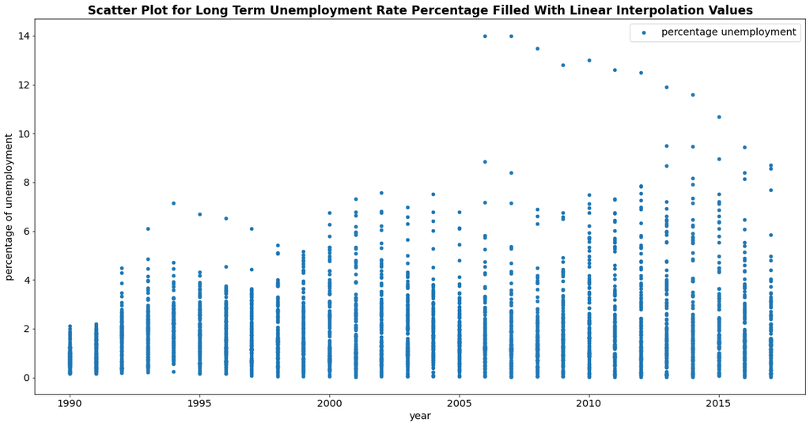

```python
df_melt_linear.plot(x='year', y='percent_unemployment', kind='scatter',
                   figsize=(20,10),
                   fontsize='x-large',
                   label="percentage unemployment")
plt.title("Scatter Plot for Long Term Unemployment Rate Percentage Filled With Linear Interpolation Values", fontdict={'fontsize': 'xx-large', 'fontweight': 'bold'})
plt.legend(fontsize='x-large',loc='best')
plt.xlabel("year", fontsize='x-large')
plt.ylabel("percentage of unemployment", fontsize='x-large');
```

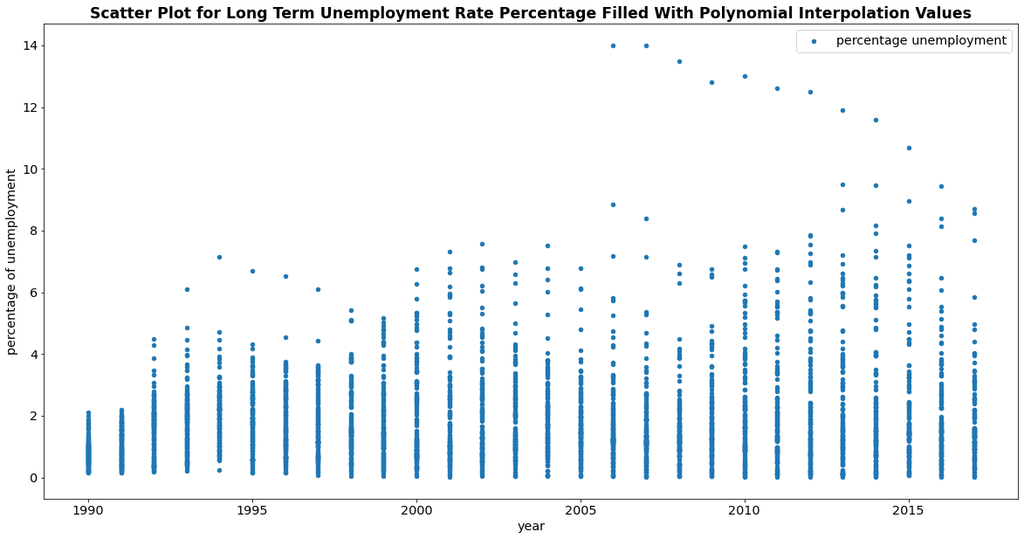

```python
df_melt_polinomial.plot(x='year', y='percent_unemployment', kind='scatter',
                       figsize=(20, 10),
                       fontsize='x-large',
                       label='percentage unemployment')
plt.title("Scatter Plot for Long Term Unemployment Rate Percentage Filled With Polynomial Interpolation Values", fontdict={'fontsize': 'xx-large', 'fontweight': 'bold'})
plt.legend(fontsize='x-large', loc='best')
plt.xlabel('year', fontsize='x-large')
plt.ylabel('percentage of unemployment', fontsize='x-large');
```

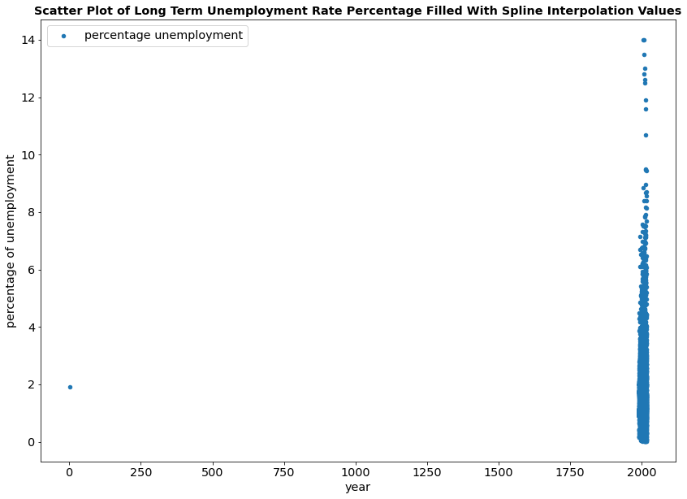

```python
df_melt_spline.plot(x='year', y='percent_unemployment', kind='scatter',
                   figsize=(14, 10),
                   fontsize='x-large',
                   label='percentage unemployment')
plt.title("Scatter Plot of Long Term Unemployment Rate Percentage Filled With Spline Interpolation Values", fontdict={'fontsize': 'x-large', 'fontweight': 'bold'})
plt.legend(fontsize='x-large', loc='best')
plt.xlabel('year', fontsize='x-large')
plt.ylabel('percentage of unemployment', fontsize='x-large');
```

```python
df_melt_spline.head()
```

|  | country | year | percent_unemployment |
| --- | --- | --- | --- |
| 0 | Albania | 1990.0 | NaN |
| 1 | Algeria | 1990.0 | NaN |
| 2 | Angola | 1990.0 | NaN |
| 3 | Argentina | 1990.0 | NaN |
| 4 | Armenia | 1990.0 | NaN |

```python
type(df_melt_spline['year'][0])
```

```
numpy.float64
```

```python
df_melt_spline['year'] = df_melt_spline['year'].astype(dtype='int64')
```

```python
type(df_melt_spline['year'][0])
```

```
numpy.int64
```

```python
df_melt_spline['percent_unemployment'].max()
```

```
14.000000000000002
```

### Deciding by plotting box plot and histogram

- The results from spline method vary
- The purpose is to fill NaN and not simply drop it
- Spline method can be very useful for sudden spike or drop in values
- For the scope of the analysis spine method may not be useful
- I will elaborate more about the scope of the analysis and limitations in Exploratary Data Analysis and Conclusion
- Most likely I am going to fill NaN with linear interpolation
- Before that I am going to plot box plots and histograms and convey the reason for filling NaN with linear interpolation

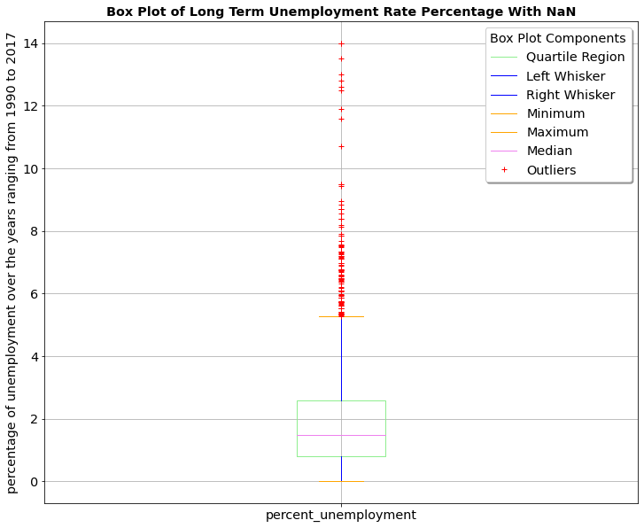

```python
color = {
    "boxes": "LightGreen",
    "whiskers": "Blue",
    "medians": "Violet",
    "caps": "Orange",
}

labels = ['Quartile Region', 'Left Whisker', 'Right Whisker', 'Minimum', 'Maximum', 'Median', 'Outliers']

df_melt['percent_unemployment'].plot(kind='box',
               figsize=(12,10),
               grid = True,
               color=color,
               sym="r+",
               fontsize='x-large')

plt.legend(title='Box Plot Components', title_fontsize='x-large', labels=labels,
           fontsize='x-large', frameon=True, fancybox=True, shadow=True)
plt.title("Box Plot of Long Term Unemployment Rate Percentage With NaN", fontdict={'fontsize': 'x-large', 'fontweight': 'bold'})
plt.ylabel("percentage of unemployment over the years ranging from 1990 to 2017", fontsize='x-large');
```

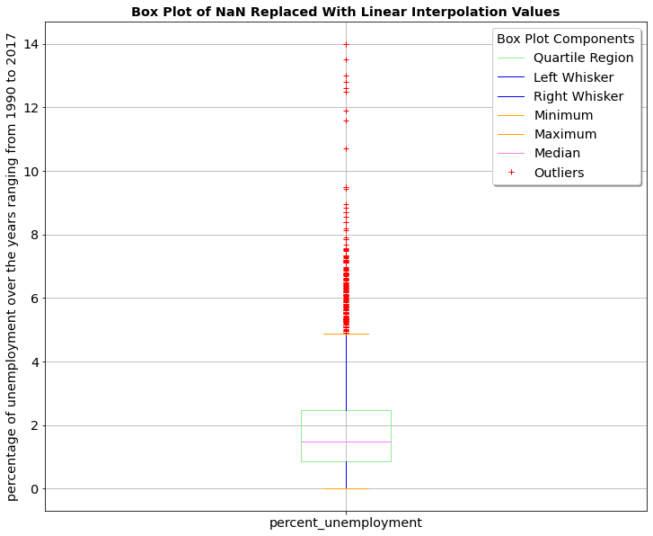

```python
color = {
    "boxes": "LightGreen",
    "whiskers": "Blue",
    "medians": "Violet",
    "caps": "Orange",
}

labels = ['Quartile Region', 'Left Whisker', 'Right Whisker', 'Minimum', 'Maximum', 'Median', 'Outliers']


df_melt_linear['percent_unemployment'].plot(kind='box',
                    figsize=(12, 10),
                    grid=True,
                    color=color,
                    sym='r+',
                    fontsize='x-large')

plt.legend(title='Box Plot Components', title_fontsize='x-large', labels=labels, fontsize='x-large',
           frameon=True, fancybox=True, shadow=True)
plt.title("Box Plot of NaN Replaced With Linear Interpolation Values", fontdict={'fontsize': 'x-large', 'fontweight': 'bold'})
plt.ylabel("percentage of unemployment over the years ranging from 1990 to 2017", fontsize='x-large');
```

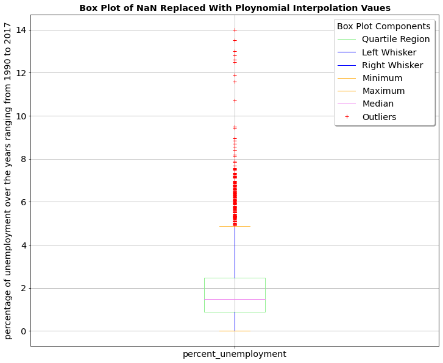

```python
color = {
    "boxes": "LightGreen",
    "whiskers": "Blue",
    "medians": "Violet",
    "caps": "Orange",
}

labels = ['Quartile Region', 'Left Whisker', 'Right Whisker', 'Minimum', 'Maximum', 'Median', 'Outliers']


df_melt_polinomial['percent_unemployment'].plot(kind='box',
                    figsize=(12, 10),
                    grid=True,
                    color=color,
                    sym='r+',
                    fontsize='x-large')

plt.legend(title='Box Plot Components', title_fontsize='x-large', labels=labels, fontsize='x-large',
           frameon=True, fancybox=True, shadow=True)
plt.title("Box Plot of NaN Replaced With Ploynomial Interpolation Vaues", fontdict={'fontsize': 'x-large', 'fontweight': 'bold'})
plt.ylabel("percentage of unemployment over the years ranging from 1990 to 2017", fontsize='x-large');
```

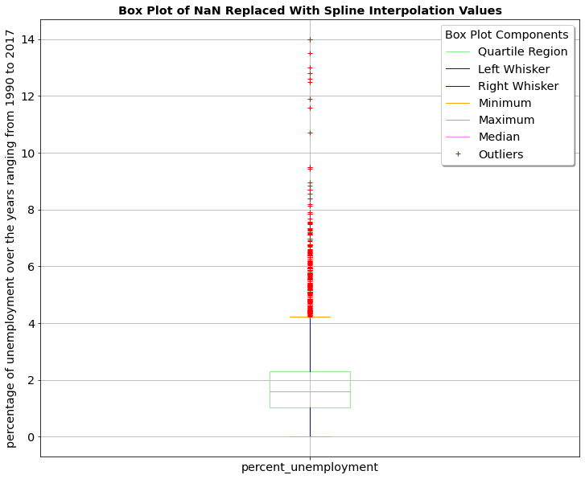

```python
color = {
    "boxes": "LightGreen",
    "whiskers": "Blue",
    "medians": "Violet",
    "caps": "Orange",
}

labels = ['Quartile Region', 'Left Whisker', 'Right Whisker', 'Minimum', 'Maximum', 'Median', 'Outliers']


df_melt_spline['percent_unemployment'].plot(kind='box',
                figsize=(12,10),
                grid=True,
                color=color,
                sym='r+',
                fontsize='x-large')

plt.legend(title='Box Plot Components', title_fontsize='x-large', labels=labels, fontsize='x-large',
           frameon=True, fancybox=True, shadow=True)
plt.title("Box Plot of NaN Replaced With Spline Interpolation Values", fontdict={'fontsize': 'x-large', 'fontweight': 'bold'})
plt.ylabel("percentage of unemployment over the years ranging from 1990 to 2017", fontsize='x-large');
```

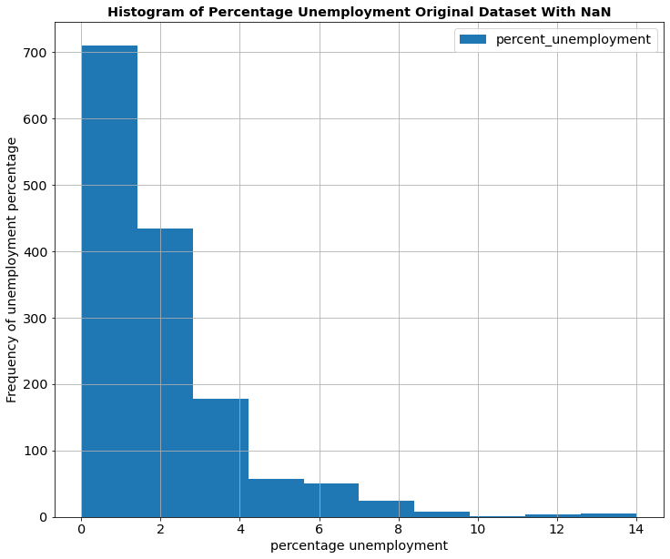

```python
plt.title("Histogram of Percentage Unemployment Original Dataset With NaN", fontdict={'fontsize': 'x-large', 'fontweight': 'bold'})
plt.xlabel("percentage unemployment", fontsize='x-large')
plt.ylabel("Frequency of unemployment percentage", fontsize='x-large')
plt.xticks(fontsize='x-large')
plt.yticks(fontsize='x-large')
df_melt['percent_unemployment'].hist(figsize=(12,10), legend=True)
plt.legend(fontsize='x-large');
```

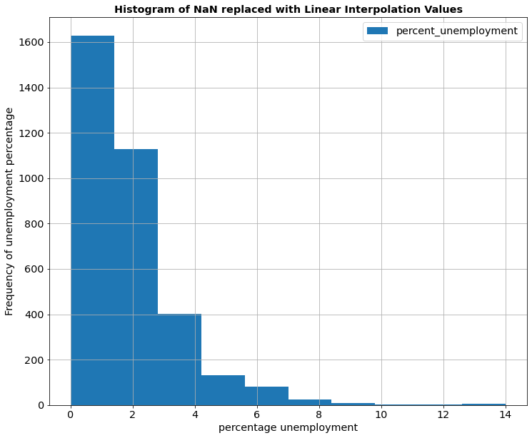

```python
plt.title("Histogram of NaN replaced with Linear Interpolation Values", fontdict={'fontsize': 'x-large', 'fontweight': 'bold'})
plt.xlabel("percentage unemployment", fontsize='x-large')
plt.ylabel("Frequency of unemployment percentage", fontsize='x-large')
plt.xticks(fontsize='x-large')
plt.yticks(fontsize='x-large')
df_melt_linear['percent_unemployment'].hist(figsize=(12, 10), legend=True)
plt.legend(fontsize='x-large');
```

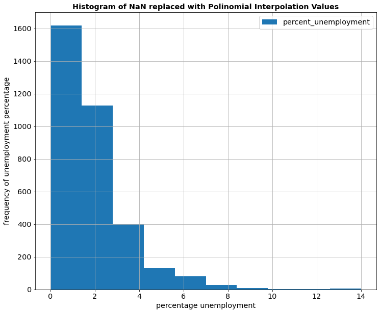

```python
plt.title("Histogram of NaN replaced with Polinomial Interpolation Values", fontdict={'fontsize': 'x-large', 'fontweight': 'bold'})
plt.xlabel("percentage unemployment", fontsize='x-large')
plt.ylabel("frequency of unemployment percentage", fontsize='x-large')
plt.xticks(fontsize='x-large')
plt.yticks(fontsize='x-large')
df_melt_polinomial['percent_unemployment'].hist(figsize=(12, 10), legend=True)
plt.legend(fontsize='x-large');
```

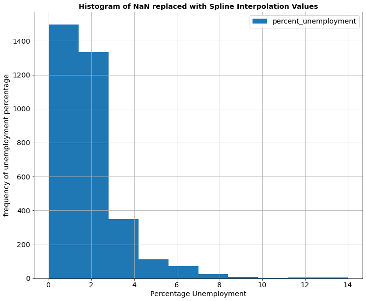

```python
plt.title("Histogram of NaN replaced with Spline Interpolation Values", fontdict={'fontsize': 'x-large', 'fontweight': 'bold'})
plt.xlabel("Percentage Unemployment", fontsize='x-large')
plt.ylabel("frequency of unemployment percentage", fontsize='x-large')
plt.xticks(fontsize='x-large')
plt.yticks(fontsize='x-large')
df_melt_spline['percent_unemployment'].hist(figsize=(12,10), legend=True)
plt.legend(fontsize='x-large');
```

```python
df_melt['percent_unemployment'].mode()
```

```
0    1.24
dtype: float64
```

```python
df_melt['percent_unemployment'].median()
```

```
1.475
```

```python
df_melt['percent_unemployment'].mean()
```

```
2.020680095108696
```

```python
df_melt_linear['percent_unemployment'].mean()
```

```
1.901045316159252
```

```python
df_melt_linear['percent_unemployment'].median()
```

```
1.4862499999999998
```

```python
df_melt_polinomial['percent_unemployment'].mean()
```

```
1.9045935995302414
```

```python
df_melt_polinomial['percent_unemployment'].median()
```

```
1.49
```

```python
df_melt_spline['percent_unemployment'].mean()
```

```
1.9172717440168683
```

```python
df_melt_spline['percent_unemployment'].median()
```

```
1.5902079572103793
```

### Comparing Observations from Linear, Polynomial, and Spline Interpolation

- The linear and polinomial interpolation produced almost similar histograms
- The results from both linear and polinomial interpolation is almost identical
- Theoritically the spline interpolation method will result in less residual error
- Also theoritically the polinomial interpolation will result in more accuracy
- But this data was spread towards width and I have reduced the width and increased the depth
- This analysis is about long term unemployment percentage of 122 countries

### Advantages of using Linear Interpolation for this Analysis

- The linear interpolation fills all the NaNs
- Theoritically it might not be the best method to fill in the NaN
- But the scope of the project is not to accurately find out percentage of unemployment in a particular country
- The analysis scope lies in better approximation
- Even though the distribution is right skewed it is not ideal to replace NaN with median
- Replacing the NaN with median or mean would mean more than 50 percentage of values are replaced with a single value

### Interpretation from Graphs

- The graphs clearly shows that the percentage unemployment rise from 1990, and then goes down towards 2017

### Interpretation from Histograms, Box Plots, Scatter Plots

- These shows that the linear interpolation methods fills in the missing values with better approximation
- Both linear interpolation and polynomial interpolation of one degree shows identical results
- The spline method tries to produce somewhat even distribution but that results in negative values
- The scope of data cleaning is only limited to filling or replacing the NaN with better approximation
- Both the linear and polinomial interpolation produce similar results
- But polinomial interpolation does not replace all the NaN which is accomplished by linear interpolation
- Since the analysis is not just about the values I am adopting linear interpolation
- Walkarounds to fix the issues related to polinomial interpolation and spline interpolation is beyond the scope of the analysis
- Further explaination of scope is in the exploratory data analysis and conclusion phase

### Few More Points on Going Ahead With Linear Interpolation

- The linear interpolation provides better technical assesment to the data
- Better assesment will lead to better approximation
- It is better to go ahead with linear interpolation rather than filling with median or mean

### Few Important Points about the Dataset that Lead to Choose Linear Interpolation

- I perfomed the tests to choose the method of interpolation on Albania and Zimbabwe
- For Zimbabwe long term unemployment for the year 2014 alone was present
- Both linear and polinomial interpolation produced similar results graphically
- Similar graphical result is sufficient for concluding based on visualization
- Furthermore, linear interpolation fills in all the NaN when filled in both directions

### Articles on Long Term Unemployment

- It is very important to know that the dataset deals with registered long term unemployment
- But I was shocked to see that no data is avaiable for some Asian countries
- The reason might be that long term unemploymnet for some countries are not registered
- It is more shocking about the news of unemployment in Zimbabwe
- In the year 2014 the long term unemployment was recorded because of lots of numbers of people who were unemployed for long term
- But may be the long term unemployment was not registered after that
- The reason why some long term unemployment is not available is beyond the scope of this analysis
- But I did get some insights
- Here is BBC a news [article](https://www.bbc.com/news/business-42116932) that questions 90 percentage of people in Zimbabwe are unemployed, as of 2017
- Here is another wikipedia [page](https://en.wikipedia.org/wiki/Unemployment) that I referred for the purpose of this analysis
- Here is another wikipedia [page](https://en.wikipedia.org/wiki/List_of_OECD_countries_by_long-term_unemployment_rate) about long term unemployment
- Data in that wikipedia page on long term unemployment rate is based on data from OECD
- I have visited the OECD website as well
- Clicking on 'Data' in OECD will generate long term unemployment until that particular time
- OECD data is collected by them
- But the data in Gapminder is only about registered long term unemployment rate
- However the wikipedia pages are helpful in finding countries that are affected by long term unemployment

### Interpreting Gapminder vs OEBD Data

- I went through the Long Term Unemployment Wikipedia page
- I see that for Greece The long term unemployment percentage for the year 2012 is 14.37
- But as per Gapminder data the long term unemployment percentage for the year 2012 is only 7.84
- As per gapminder data the long term unemployment is half that of long term unemployment data by OEBD
- But the important thing to note is that gapminder data is limited to only reported long term unemployment percentage
- I have filtered the long term unemployment percentage for Greece in the year 2012
- The dataframe df_melt is a melted dataframe with NaN
- The dataframe df_melt_linear is filled with values from linear interpolation
- Further I have filtered both these dataframes without year
- The df_melt_linear values for Greece further shows that linear interpolation fills in NaN with approximate values within bounds

### Article on Interpolation Techniques

- Wikipedia artile on [Linear Interpolation](https://en.wikipedia.org/wiki/Linear_interpolation)
- Wikipedia article on [Polinomial Interpolation](https://en.wikipedia.org/wiki/Polynomial_interpolation)
- Wikipedia article on [Spline Interpolation](https://en.wikipedia.org/wiki/Spline_interpolation)
- Based on the data from Gapminder and also the external references I have decided that linear interpolation is sufficient for this analysis

```python
df_melt_linear
```

|  | country | year | percent_unemployment |
| --- | --- | --- | --- |
| 0 | Albania | 1990 | 1.240 |
| 1 | Algeria | 1990 | 1.240 |
| 2 | Angola | 1990 | 1.240 |
| 3 | Argentina | 1990 | 1.240 |
| 4 | Armenia | 1990 | 1.240 |
| ... | ... | ... | ... |
| 3411 | Vanuatu | 2017 | 0.145 |
| 3412 | Venezuela | 2017 | 0.145 |
| 3413 | Vietnam | 2017 | 0.145 |
| 3414 | Yemen | 2017 | 0.145 |
| 3415 | Zimbabwe | 2017 | 0.145 |

3416 rows × 3 columns

```python
df_melt_linear.query('country == "Greece" & year == 2012')
```

|  | country | year | percent_unemployment |
| --- | --- | --- | --- |
| 2727 | Greece | 2012 | 7.84 |

```python
df_melt.query('country == "Greece" & year == 2012')
```

|  | country | year | percent_unemployment |
| --- | --- | --- | --- |
| 2727 | Greece | 2012 | 7.84 |

```python
df_melt_linear.query('country == "Greece"')
```

|  | country | year | percent_unemployment |
| --- | --- | --- | --- |
| 43 | Greece | 1990 | 1.474000 |
| 165 | Greece | 1991 | 0.985556 |
| 287 | Greece | 1992 | 2.090000 |
| 409 | Greece | 1993 | 2.320000 |
| 531 | Greece | 1994 | 2.510000 |
| 653 | Greece | 1995 | 2.540000 |
| 775 | Greece | 1996 | 2.820000 |
| 897 | Greece | 1997 | 2.840000 |
| 1019 | Greece | 1998 | 3.300000 |
| 1141 | Greece | 1999 | 3.640000 |
| 1263 | Greece | 2000 | 3.430000 |
| 1385 | Greece | 2001 | 3.030000 |
| 1507 | Greece | 2002 | 3.050000 |
| 1629 | Greece | 2003 | 2.990000 |
| 1751 | Greece | 2004 | 3.340000 |
| 1873 | Greece | 2005 | 3.050000 |
| 1995 | Greece | 2006 | 2.850000 |
| 2117 | Greece | 2007 | 2.420000 |
| 2239 | Greece | 2008 | 2.140000 |
| 2361 | Greece | 2009 | 2.470000 |
| 2483 | Greece | 2010 | 3.490000 |
| 2605 | Greece | 2011 | 5.170000 |
| 2727 | Greece | 2012 | 7.840000 |
| 2849 | Greece | 2013 | 9.500000 |
| 2971 | Greece | 2014 | 9.480000 |
| 3093 | Greece | 2015 | 8.970000 |
| 3215 | Greece | 2016 | 8.400000 |
| 3337 | Greece | 2017 | 7.680000 |

```python
df_melt.query('country == "Greece"')
```

|  | country | year | percent_unemployment |
| --- | --- | --- | --- |
| 43 | Greece | 1990 | NaN |
| 165 | Greece | 1991 | NaN |
| 287 | Greece | 1992 | 2.09 |
| 409 | Greece | 1993 | 2.32 |
| 531 | Greece | 1994 | 2.51 |
| 653 | Greece | 1995 | 2.54 |
| 775 | Greece | 1996 | 2.82 |
| 897 | Greece | 1997 | 2.84 |
| 1019 | Greece | 1998 | 3.30 |
| 1141 | Greece | 1999 | 3.64 |
| 1263 | Greece | 2000 | 3.43 |
| 1385 | Greece | 2001 | 3.03 |
| 1507 | Greece | 2002 | 3.05 |
| 1629 | Greece | 2003 | 2.99 |
| 1751 | Greece | 2004 | 3.34 |
| 1873 | Greece | 2005 | 3.05 |
| 1995 | Greece | 2006 | 2.85 |
| 2117 | Greece | 2007 | 2.42 |
| 2239 | Greece | 2008 | 2.14 |
| 2361 | Greece | 2009 | 2.47 |
| 2483 | Greece | 2010 | 3.49 |
| 2605 | Greece | 2011 | 5.17 |
| 2727 | Greece | 2012 | 7.84 |
| 2849 | Greece | 2013 | 9.50 |
| 2971 | Greece | 2014 | 9.48 |
| 3093 | Greece | 2015 | 8.97 |
| 3215 | Greece | 2016 | 8.40 |
| 3337 | Greece | 2017 | 7.68 |

### Cleaned Data Set

- df is the original dataset
- df_melt is the melted dataset
- df_melt_linear is the dataset filled with values obtained from linear interpolation
- df_clean which I am going to create will be the cleaned dataset that will be used for 'Exploratory Data Analysis' & 'Conclusion'

```python
df_melt.isnull().sum() #Melted Dataframe with Nan
```

```
country                    0
year                       0
percent_unemployment    1944
dtype: int64
```

```python
df_clean  = df_melt.copy() # Making a copy of the dataframe
```

```python
df_clean.sample(10)
```

|  | country | year | percent_unemployment |
| --- | --- | --- | --- |
| 856 | Angola | 1997 | NaN |
| 1009 | Estonia | 1998 | 2.790 |
| 225 | Sweden | 1991 | 0.406 |
| 2327 | Belarus | 2009 | NaN |
| 426 | Luxembourg | 1993 | 0.550 |
| 1636 | Ireland | 2003 | 1.170 |
| 2966 | France | 2014 | 2.860 |
| 844 | Ukraine | 1996 | NaN |
| 859 | Australia | 1997 | 1.850 |
| 2824 | Cameroon | 2013 | NaN |

```python
df_clean['percent_unemployment'] = df_clean['percent_unemployment'].interpolate(method='linear', limit_direction = "both")
```

### Checking One Last Time

- Just checking whether the df_clean is similar to the df_melt_linear
- Going to use few methods info(), shape, describe()
- Check the datatypes
- Plot histogram and box plot

```python
df_clean.head()
```

|  | country | year | percent_unemployment |
| --- | --- | --- | --- |
| 0 | Albania | 1990 | 1.24 |
| 1 | Algeria | 1990 | 1.24 |
| 2 | Angola | 1990 | 1.24 |
| 3 | Argentina | 1990 | 1.24 |
| 4 | Armenia | 1990 | 1.24 |

```python
df_clean.tail()
```

|  | country | year | percent_unemployment |
| --- | --- | --- | --- |
| 3411 | Vanuatu | 2017 | 0.145 |
| 3412 | Venezuela | 2017 | 0.145 |
| 3413 | Vietnam | 2017 | 0.145 |
| 3414 | Yemen | 2017 | 0.145 |
| 3415 | Zimbabwe | 2017 | 0.145 |

```python
df_clean.isnull().sum()
```

```
country                 0
year                    0
percent_unemployment    0
dtype: int64
```

```python
df_clean.info()
```

```
<class 'pandas.core.frame.DataFrame'>
RangeIndex: 3416 entries, 0 to 3415
Data columns (total 3 columns):
 #   Column                Non-Null Count  Dtype
---  ------                --------------  -----
 0   country               3416 non-null   object
 1   year                  3416 non-null   int64
 2   percent_unemployment  3416 non-null   float64
dtypes: float64(1), int64(1), object(1)
memory usage: 80.2+ KB
```

```python
df_clean.shape
```

```
(3416, 3)
```

```python
df_clean['country'].nunique() # Counrties are duplicated because of using melt
```

```
122
```

```python
df_clean['year'].nunique() # Years are duplicated because of using melt
```

```
28
```

```python
df_clean.describe()
```

|  | year | percent_unemployment |
| --- | --- | --- |
| count | 3416.00000 | 3416.000000 |
| mean | 2003.50000 | 1.901045 |
| std | 8.07893 | 1.573176 |
| min | 1990.00000 | 0.014200 |
| 25% | 1996.75000 | 0.875000 |
| 50% | 2003.50000 | 1.486250 |
| 75% | 2010.25000 | 2.476250 |
| max | 2017.00000 | 14.000000 |

```python
df_melt_linear.describe()
```

|  | year | percent_unemployment |
| --- | --- | --- |
| count | 3416.00000 | 3416.000000 |
| mean | 2003.50000 | 1.901045 |
| std | 8.07893 | 1.573176 |
| min | 1990.00000 | 0.014200 |
| 25% | 1996.75000 | 0.875000 |
| 50% | 2003.50000 | 1.486250 |
| 75% | 2010.25000 | 2.476250 |
| max | 2017.00000 | 14.000000 |

### Reason For Repeating Few Steps

- I could have simply proceeded with df_melt_linear but that is not a meaningful variable name in context of 'Exploratory Data Analysis'
- I could have proceeded with df_clean immediately after creating it. But any error would lead to rework or terrible mistakes
- Furthermore, the data cleaning also included comparision between interpolation methods
- I did not want to conclude the data cleaning section by just comparing the cleaning methods and chosing a method
- I preferred to conclude this section by creating a cleaned data frame and verifying it and use that alone for 'Exploratory Data Analysis'
- This involved few more steps but helps in maintaining consistency in the analysis process and helps to avoid mistakes
- To conclude df is the original dataframe, df_melt is the melted dataframe. Both these dataframes contain misssing values
- df_clean is the cleaned dataframe and I have used linear interpolation to fill in the missing values

## Exploratory Data Analysis

### Q1. The long term unemployment rate percentage over years is decreasing or increasing or it's at a steady rate?

```python
# Creating a pandas dataframe by filtering the year and percentage of unemployment
df_yearly_unemployment = df_clean.groupby('year')['percent_unemployment'].mean().reset_index()
```

```python
type(df_yearly_unemployment)
```

```
pandas.core.frame.DataFrame
```

```python
df_yearly_unemployment.nunique()
```

```
year                    28
percent_unemployment    28
dtype: int64
```

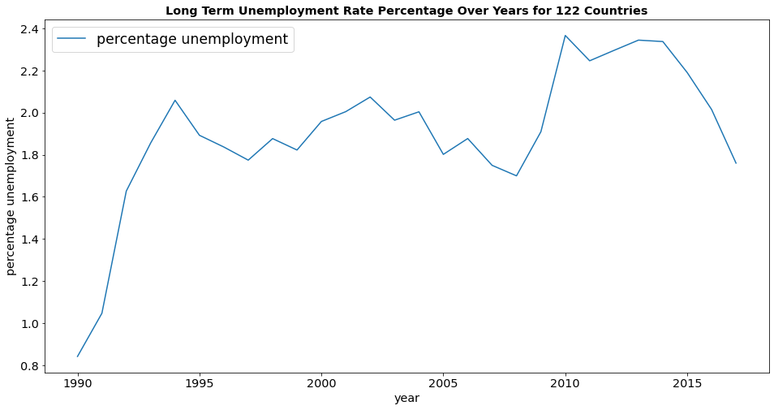

```python
plt.figure(figsize = (16, 8))
sb.lineplot(x = 'year', y='percent_unemployment', data=df_yearly_unemployment, label='percentage unemployment')
plt.xticks(fontsize='x-large')
plt.yticks(fontsize='x-large')
plt.legend( fontsize='xx-large',loc='best')
plt.title("Long Term Unemployment Rate Percentage Over Years for 122 Countries", fontdict={'fontsize': 'x-large', 'fontweight': 'bold'})
plt.xlabel("year", fontsize='x-large')
plt.ylabel("percentage unemployment", fontsize='x-large');
```

```python
df_yearly_unemployment.nunique()
```

```
year                    28
percent_unemployment    28
dtype: int64
```

### Making use of Window Functions

- I am going to plot using rolling method
- I am applying the method of finding moving averages which I learned in project one and applying it here
- I am going to group the data by 122 countries

```python
df_yearly_unemployment_rolling = df_clean.groupby('year')['percent_unemployment'].rolling(61).mean().reset_index()
```

```python
type(df_yearly_unemployment_rolling)
```

```
pandas.core.frame.DataFrame
```

```python
df_yearly_unemployment_rolling.nunique()
```

```
year                      28
level_1                 3416
percent_unemployment    1735
dtype: int64
```

```python
df_yearly_unemployment_rolling.sample(10)
```

|  | year | level_1 | percent_unemployment |
| --- | --- | --- | --- |
| 2022 | 2006 | 2022 | 1.771307 |
| 1271 | 2000 | 1271 | NaN |
| 684 | 1995 | 684 | 1.646740 |
| 2692 | 2012 | 2692 | NaN |
| 1784 | 2004 | 1784 | 1.886752 |
| 1674 | 2003 | 1674 | 1.750728 |
| 1422 | 2001 | 1422 | 1.845049 |
| 193 | 1991 | 193 | 1.011102 |
| 506 | 1994 | 506 | NaN |
| 2434 | 2009 | 2434 | 1.905259 |

### Why 61 For Rolling Function

- The rolling() accepts only integer values
- level_1 3416 indicates the total number of countries, including repition(because of melt)
- 3416 / 28 = 122 which is the unique number of countries
- Now plotting the line graph would render a result where average is grouped over 61 countries
- It is similar to splitting countries into 2 different groups
- This would render a slightly easy to interpret graph

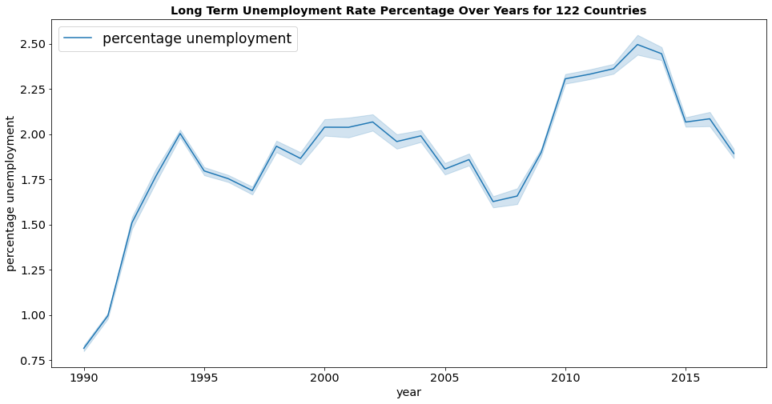

```python
plt.figure(figsize = (16, 8))
sb.lineplot( x= 'year', y='percent_unemployment', data=df_yearly_unemployment_rolling, label='percentage unemployment')
plt.xticks(fontsize='x-large')
plt.yticks(fontsize='x-large')
plt.legend(fontsize='xx-large',loc='best')
plt.title("Long Term Unemployment Rate Percentage Over Years for 122 Countries", fontdict={'fontsize': 'x-large', 'fontweight': 'bold'})
plt.xlabel("year", fontsize='x-large')
plt.ylabel("percentage unemployment", fontsize='x-large');
```

### Observations About Long Term Unemployment Rate Percentage Over Years

- The long term unemployment percentage reached peak values in the years 1994, 2002, 2010
- The average long term unemployment was at the lowest at 1900 (It is the start year)
- It reached noticable lower percentage in the year 2008. But this is is not the year of absolute minimum unemployment percentage
- The long term unemployment percentage over years is non linear

### Q2. What is the range of long term unemployment rate over years? Which is more, countries with low long term unemployment rate percentage or high long term unemployment rate percentage?

### Categorizing Long Term Unemployment Percentage

- I am going to categorize long term unemployment percentage into four categories
- The four categories are low, high, higher, severe
- I am going to split into categories by performing quct on the 'precentage_unemployment' column in the df_clean dataframe
- I am going to find out the count, max, and min of the various categories of unemployment
- After performing qcut I am going to use pd.cut
- The purpose of qcut is to ensue that lower unemployment percentage is lesser than the higher
- The desired output is low < high < higher < severe
- I ensure that I get the desired output using qcut and then I use cut
- I am going to plot the results from qcut in pie chart
- After that I am going to categorize the data and transform it to answer the next question
- The whole purpose of performing both qcut and cut is to verify and then categorize

```python
# making a copy of the df_clean dataframe before performing qcut
df_clean_qcut = df_clean.copy()
bins = pd.qcut(df_clean_qcut['percent_unemployment'], 4, labels = ['low', 'high', 'higher', 'severe'])
```

```python
type(bins)
```

```
pandas.core.series.Series
```

```python
bins
```

```
0       high
1       high
2       high
3       high
4       high
        ...
3411     low
3412     low
3413     low
3414     low
3415     low
Name: percent_unemployment, Length: 3416, dtype: category
Categories (4, object): ['low' < 'high' < 'higher' < 'severe']
```

```python
unemployment_category = (pd.Series(df_clean_qcut['percent_unemployment'])
                            .groupby(bins)
                            .agg(['count', 'min', 'max'])
                            .reset_index())
```

```python
type(unemployment_category)
```

```
pandas.core.frame.DataFrame
```

```python
unemployment_category
```

|  | percent_unemployment | count | min | max |
| --- | --- | --- | --- | --- |
| 0 | low | 854 | 0.014200 | 0.874 |
| 1 | high | 854 | 0.875333 | 1.485 |
| 2 | higher | 854 | 1.487500 | 2.475 |
| 3 | severe | 854 | 2.480000 | 14.000 |

```python
df_clean_qcut['percent_unemployment'].describe()
```

```
count    3416.000000
mean        1.901045
std         1.573176
min         0.014200
25%         0.875000
50%         1.486250
75%         2.476250
max        14.000000
Name: percent_unemployment, dtype: float64
```

```python
# making a copy of df_clean dataframe and performing cut
df_clean_cut = df_clean.copy()
```

```python
# performing cut

bin_edges = [0.014, 0.875, 1.486250, 2.476250, 14.00001]
bin_names = ['low', 'high', 'higher', 'severe']
unemployment_category_cut = pd.cut(df_clean_cut['percent_unemployment'], bin_edges, labels=bin_names)
```

```python
type(unemployment_category_cut)
```

```
pandas.core.series.Series
```

```python
## As expected unemployment_category_cut is a Series
## I am going to insert this Series into df_clean_cut dataframe with a column name 'severity'
## A column name 'severity_of_unemployment' will be long so I name the column 'severity'
```

```python
df_clean_cut['severity'] = unemployment_category_cut
```

```python
df_clean_cut.head()
```

|  | country | year | percent_unemployment | severity |
| --- | --- | --- | --- | --- |
| 0 | Albania | 1990 | 1.24 | high |
| 1 | Algeria | 1990 | 1.24 | high |
| 2 | Angola | 1990 | 1.24 | high |
| 3 | Argentina | 1990 | 1.24 | high |
| 4 | Armenia | 1990 | 1.24 | high |

```python
df_clean_cut['severity'].value_counts()
```

```
low       854
high      854
higher    854
severe    854
Name: severity, dtype: int64
```

```python
unemployment_category
```

|  | percent_unemployment | count | min | max |
| --- | --- | --- | --- | --- |
| 0 | low | 854 | 0.014200 | 0.874 |
| 1 | high | 854 | 0.875333 | 1.485 |
| 2 | higher | 854 | 1.487500 | 2.475 |
| 3 | severe | 854 | 2.480000 | 14.000 |

### Observation from cut and qcut

- Both cut and qcut have rendered similar results
- It is obvious that both will produce similar results
- While using cut method I need to set the minimum value slightly less than the actual value and maximum value slightly more than the actual value. In bin edges I have set starting edge as 0.014 % instead of 0.0142 %.
- Similarly I have set the ending bin edge as 14.00001 % instead of 14.000000 %.
- The reason for choosing starting bin edge slightly less than the minimum value, and the ending bin edge slightly more than the maximum value is that, the cut method cuts based on values "greater than the starting edge and lesser than the ending edge"
- I will use the dataframe manipulated after performing cut to produce categorical data
- I am going to make use of pandas crosstab to find out which countries have been through all the ranges of unemployment
- In order to find out which countries have witnessed all the categories of unemployment I cut it ahead along with qcut
- I am going to use the results from qcut to produce a pie chart

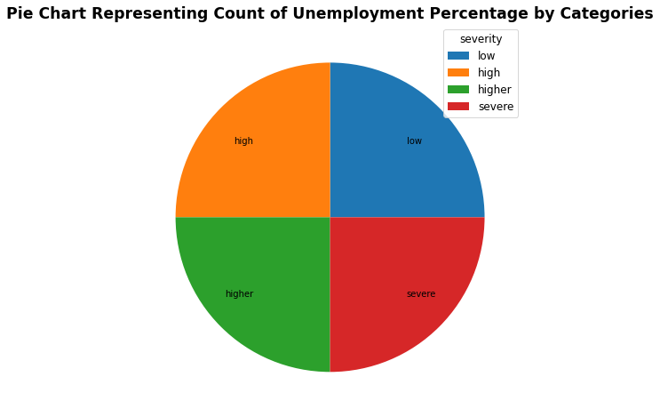

```python
plt.figure(figsize=(10, 8))
plt.title("Pie Chart Representing Count of Unemployment Percentage by Categories",
          fontdict={'fontsize': 'xx-large', 'fontweight': 'bold'})
plt.pie(unemployment_category['count'], labels=unemployment_category['percent_unemployment'], labeldistance=0.7)
plt.legend(title='severity', title_fontsize='large', loc='best', fontsize='large');
```

```python
df_clean_cut['percent_unemployment'].median()
```

```
1.4862499999999998
```

### Which is more, lower long term unemployment or higher long term unemployment?

- Since quartile cut was done the data was split equally for all the four categories
- Rather than categorizing unemployment as lower and then low I have categorized it into low and high
- Long term unemployment is a serious issue. So I have categorized data to indicate that it is a very sensitive data set
- Overall the percentage of long term unemployment shared by each category is the same
- The ratio of count of percentage of unemployment from 2.48 to 14 percentage is similar to that of low, high, higher categories of unemployment
- The whole purpose of this section is to add a column to the dataframe and classify the unemployment percentage into categories
- Splitting the unemployment by categories will be very helpful in filtering the data based on categories
- Since I have classified the unemployment percentage into low, high, higher, and severe, the long term unemployment percentage of higher unemployment is more than the lower unemployment percentage
- This means that as per the data from 1990 to 2017 all the 122 countries together have encountered unemployment percentage in the range 2.48 to 14 percentage for about 25 percentage of times
- Further the median falls in the high category
- I have considered unemployment percentage between 25% and 50% quartile values as high
- The answer to the question is highly dependent on how the unemployment rate is categorized
- Since I have taken all the countries and all the years into consideration, I have classified 25% and 50% quartile values as high, the higher unemployment percentage is more than the lower unemployment percentage

### Splitting by Low Unemployment and High Unemployment

```python
median_unemployment = df_clean_cut['percent_unemployment'].median()
low_unemployment = df_clean_cut.query('percent_unemployment < {}'.format(median_unemployment))
high_unemployment = df_clean_cut.query('percent_unemployment >= {}'.format(median_unemployment))
```

```python
low_unemployment
```

|  | country | year | percent_unemployment | severity |
| --- | --- | --- | --- | --- |
| 0 | Albania | 1990 | 1.240 | high |
| 1 | Algeria | 1990 | 1.240 | high |
| 2 | Angola | 1990 | 1.240 | high |
| 3 | Argentina | 1990 | 1.240 | high |
| 4 | Armenia | 1990 | 1.240 | high |
| ... | ... | ... | ... | ... |
| 3411 | Vanuatu | 2017 | 0.145 | low |
| 3412 | Venezuela | 2017 | 0.145 | low |
| 3413 | Vietnam | 2017 | 0.145 | low |
| 3414 | Yemen | 2017 | 0.145 | low |
| 3415 | Zimbabwe | 2017 | 0.145 | low |

1708 rows × 4 columns

```python
high_unemployment
```

|  | country | year | percent_unemployment | severity |
| --- | --- | --- | --- | --- |
| 37 | Finland | 1990 | 1.628200 | higher |
| 38 | France | 1990 | 1.990000 | higher |
| 39 | Gambia | 1990 | 1.886800 | higher |
| 40 | Georgia | 1990 | 1.783600 | higher |
| 41 | Germany | 1990 | 1.680400 | higher |
| ... | ... | ... | ... | ... |
| 3402 | Timor-Leste | 2017 | 1.516667 | higher |
| 3403 | Tunisia | 2017 | 1.543333 | higher |
| 3404 | Turkey | 2017 | 1.570000 | higher |
| 3405 | Uganda | 2017 | 1.585000 | higher |
| 3406 | Ukraine | 2017 | 1.600000 | higher |

1708 rows × 4 columns

### Observations from Splitting at Median

- First of all splitting at median ensures that the values obtained by using cut and qcut are correct
- As expected the results are split into two equal halves with low and high categories of unemployment in one category
- And higher and severe unemployment percentage in another category
- There is no guideline however how much percentage of long term unemployment is higher
- So I have considered values from 25% quartile values as high unemployment
- This concludes the fact that based on type of method used for filling NaN unemployment category will vary
- Further based on the way the unemployment is categorized either of higher or lower unemployment percentage will be more
- It's because I have split the severity category into low, high, higher, and highest the long term unemployment percentage of higher unemployment percentage is more than the lower unemployment percentage

### Q3. Does any country or some countries have experienced or witnessed all the ranges of long term unemployment rate from the lowest rate to highest rate over years?

### Steps involved

- I am going to create a copy of the dataframe df_clean_cut
- And then I create another dataframe by implementing pandas crosstab method

```python
df_clean_cut_crosstab = df_clean_cut.copy()
```

```python
# The purpose of copying the df_clean_cut dataframe is to retain the severity column
# At the same time I prefer to create a new dataframe while filtering values
# so I have created another dataframe df_clean_crosstab
df_clean_cut_crosstab.head()
```

|  | country | year | percent_unemployment | severity |
| --- | --- | --- | --- | --- |
| 0 | Albania | 1990 | 1.24 | high |
| 1 | Algeria | 1990 | 1.24 | high |
| 2 | Angola | 1990 | 1.24 | high |
| 3 | Argentina | 1990 | 1.24 | high |
| 4 | Armenia | 1990 | 1.24 | high |

```python
df_clean_cut_crosstab.query('country == "North Macedonia"')
```

|  | country | year | percent_unemployment | severity |
| --- | --- | --- | --- | --- |
| 78 | North Macedonia | 1990 | 0.991333 | high |
| 200 | North Macedonia | 1991 | 1.364667 | high |
| 322 | North Macedonia | 1992 | 1.556667 | higher |
| 444 | North Macedonia | 1993 | 1.566667 | higher |
| 566 | North Macedonia | 1994 | 1.306667 | high |
| 688 | North Macedonia | 1995 | 1.336667 | high |
| 810 | North Macedonia | 1996 | 0.890667 | high |
| 932 | North Macedonia | 1997 | 0.785333 | low |
| 1054 | North Macedonia | 1998 | 0.738667 | low |
| 1176 | North Macedonia | 1999 | 0.602667 | low |
| 1298 | North Macedonia | 2000 | 0.528333 | low |
| 1420 | North Macedonia | 2001 | 0.500000 | low |
| 1542 | North Macedonia | 2002 | 0.565667 | low |
| 1664 | North Macedonia | 2003 | 0.542000 | low |
| 1786 | North Macedonia | 2004 | 0.622667 | low |
| 1908 | North Macedonia | 2005 | 0.590000 | low |
| 2030 | North Macedonia | 2006 | 14.000000 | severe |
| 2152 | North Macedonia | 2007 | 14.000000 | severe |
| 2274 | North Macedonia | 2008 | 13.500000 | severe |
| 2396 | North Macedonia | 2009 | 12.800000 | severe |
| 2518 | North Macedonia | 2010 | 13.000000 | severe |
| 2640 | North Macedonia | 2011 | 12.600000 | severe |
| 2762 | North Macedonia | 2012 | 12.500000 | severe |
| 2884 | North Macedonia | 2013 | 11.900000 | severe |
| 3006 | North Macedonia | 2014 | 11.600000 | severe |
| 3128 | North Macedonia | 2015 | 10.700000 | severe |
| 3250 | North Macedonia | 2016 | 9.440000 | severe |
| 3372 | North Macedonia | 2017 | 8.700000 | severe |

```python
df_clean_crosstab = pd.crosstab(df_clean_cut_crosstab['country'], df_clean_cut_crosstab['severity'],
                                margins=True).reset_index()
```

```python
type(df_clean_crosstab)
```

```
pandas.core.frame.DataFrame
```

```python
df_clean_crosstab.head()
```

| severity | country | low | high | higher | severe | All |
| --- | --- | --- | --- | --- | --- | --- |
| 0 | Albania | 4 | 11 | 3 | 10 | 28 |
| 1 | Algeria | 0 | 13 | 6 | 9 | 28 |
| 2 | Angola | 0 | 11 | 14 | 3 | 28 |
| 3 | Argentina | 5 | 11 | 9 | 3 | 28 |
| 4 | Armenia | 3 | 13 | 8 | 4 | 28 |

```python
df_clean_crosstab.query('country == "North Macedonia"')
```

| severity | country | low | high | higher | severe | All |
| --- | --- | --- | --- | --- | --- | --- |
| 78 | North Macedonia | 9 | 5 | 2 | 12 | 28 |

### Note

- Initially I specified bin edges of cut exactly as the values obtained from describe method
- Later I noted here that two NaNs were there for North Macedonia because the 14% value was ignored
- As explained earlier I changed the starting and ending bin edges and I got the right result

### Observations after Using Pandas Crosstab

- countries with low = 0 means that it has not witnessed lower unemployment rate
- countries which have low, high, higher, and severe greater than one would mean that those countries gone through all categories of unemployment

```python
df_clean_crosstab.query('low > 1 & high > 1 & higher > 1 & severe > 1')
```

| severity | country | low | high | higher | severe | All |
| --- | --- | --- | --- | --- | --- | --- |
| 0 | Albania | 4 | 11 | 3 | 10 | 28 |
| 3 | Argentina | 5 | 11 | 9 | 3 | 28 |
| 4 | Armenia | 3 | 13 | 8 | 4 | 28 |
| 5 | Australia | 5 | 15 | 6 | 2 | 28 |
| 6 | Austria | 3 | 21 | 2 | 2 | 28 |
| 12 | Bhutan | 2 | 11 | 5 | 10 | 28 |
| 13 | Bolivia | 11 | 2 | 8 | 7 | 28 |
| 17 | Cambodia | 2 | 4 | 14 | 8 | 28 |
| 18 | Cameroon | 2 | 13 | 11 | 2 | 28 |
| 22 | Colombia | 2 | 18 | 4 | 4 | 28 |
| 23 | Costa Rica | 3 | 12 | 8 | 5 | 28 |
| 24 | Cote d'Ivoire | 3 | 7 | 5 | 13 | 28 |
| 25 | Croatia | 3 | 6 | 3 | 16 | 28 |
| 26 | Cuba | 5 | 6 | 9 | 8 | 28 |
| 27 | Cyprus | 12 | 7 | 5 | 4 | 28 |
| 28 | Czech Republic | 5 | 4 | 11 | 8 | 28 |
| 29 | Denmark | 8 | 11 | 7 | 2 | 28 |
| 32 | Egypt | 3 | 3 | 7 | 15 | 28 |
| 33 | Estonia | 2 | 4 | 5 | 17 | 28 |
| 34 | Eswatini | 2 | 3 | 8 | 15 | 28 |
| 35 | Ethiopia | 3 | 5 | 8 | 12 | 28 |
| 44 | Guatemala | 9 | 4 | 3 | 12 | 28 |
| 49 | Iran | 2 | 8 | 7 | 11 | 28 |
| 50 | Ireland | 3 | 7 | 4 | 14 | 28 |
| 51 | Israel | 14 | 9 | 2 | 3 | 28 |
| 55 | Kyrgyz Republic | 8 | 8 | 6 | 6 | 28 |
| 56 | Lao | 8 | 2 | 4 | 14 | 28 |
| 58 | Liberia | 9 | 2 | 2 | 15 | 28 |
| 59 | Lithuania | 7 | 3 | 3 | 15 | 28 |
| 70 | Montenegro | 11 | 5 | 5 | 7 | 28 |
| 71 | Morocco | 10 | 6 | 7 | 5 | 28 |
| 72 | Myanmar | 10 | 6 | 8 | 4 | 28 |
| 73 | Namibia | 8 | 8 | 8 | 4 | 28 |
| 74 | Nepal | 6 | 10 | 8 | 4 | 28 |
| 77 | Nicaragua | 7 | 6 | 4 | 11 | 28 |
| 78 | North Macedonia | 9 | 5 | 2 | 12 | 28 |
| 81 | Palestine | 2 | 4 | 5 | 17 | 28 |
| 83 | Paraguay | 10 | 8 | 5 | 5 | 28 |
| 86 | Poland | 2 | 2 | 4 | 20 | 28 |
| 87 | Portugal | 3 | 5 | 7 | 13 | 28 |
| 89 | Romania | 3 | 2 | 19 | 4 | 28 |
| 90 | Russia | 3 | 2 | 17 | 6 | 28 |
| 91 | Rwanda | 3 | 5 | 8 | 12 | 28 |
| 92 | Samoa | 5 | 3 | 4 | 16 | 28 |
| 99 | South Africa | 4 | 4 | 6 | 14 | 28 |
| 101 | Spain | 2 | 2 | 2 | 22 | 28 |
| 102 | Sri Lanka | 2 | 9 | 5 | 12 | 28 |
| 103 | Sweden | 5 | 11 | 9 | 3 | 28 |
| 109 | Tunisia | 3 | 12 | 11 | 2 | 28 |
| 114 | United Kingdom | 2 | 14 | 8 | 4 | 28 |
| 120 | Yemen | 8 | 10 | 5 | 5 | 28 |
| 121 | Zimbabwe | 6 | 9 | 4 | 9 | 28 |
| 122 | All | 854 | 854 | 854 | 854 | 3416 |

```python
df_clean_crosstab.query('low > 1 & high > 1 & higher > 1 & severe > 1').count()
```

```
severity
country    53
low        53
high       53
higher     53
severe     53
All        53
dtype: int64
```

## Dataframe with Low High Higher and Severe Category

- I am creating a new dataframe with low, high, higher, and severe categories greater than 1
- I will drop the index
- And then I will plot bar plots

```python
df_crosstab_filtered = df_clean_crosstab.query('low > 1 & high > 1 & higher > 1 & severe > 1')
```

```python
type(df_crosstab_filtered)
```

```
pandas.core.frame.DataFrame
```

```python
df_crosstab_filtered.info()
```

```
<class 'pandas.core.frame.DataFrame'>
Int64Index: 53 entries, 0 to 122
Data columns (total 6 columns):
 #   Column   Non-Null Count  Dtype
---  ------   --------------  -----
 0   country  53 non-null     object
 1   low      53 non-null     int64
 2   high     53 non-null     int64
 3   higher   53 non-null     int64
 4   severe   53 non-null     int64
 5   All      53 non-null     int64
dtypes: int64(5), object(1)
memory usage: 2.9+ KB
```

### Observations After Filtering

- 52 out of 122 countries has gone through low, high, higher, and severe long term unemployment rate over years
- Country inclues "All", I will remove it in the following cell
- I could see North Macedonia as well as Russia
- I had already plotted graph for Russia. Russia had only 2 missing values.
- Further, North Macedonia has highest long term unemployment rate
- Obviously because of using linear interpolation some of the NaN in North Macedonia was filled with lower values of uenmployment percentage
- Further developed countries like United Kingdom, Australia is also in the list of 52 countries
- While it can't be exactly concluded that exactly 52 countries have witnessed or been through all categories of unemployment
- It is definitely sure that some countries have witnessed low, high, higher, and severe unemployment rate over years

```python
df_crosstab_plot = df_crosstab_filtered.loc[:, ['country', 'low', 'high', 'higher', 'severe']]
```

```python
index = df_crosstab_plot.query('country == "All"').index
```

```python
index
```

```
Int64Index([122], dtype='int64')
```

```python
df_crosstab_plot.drop(index, inplace=True)
```

```python
df_crosstab_plot.info()
```

```
<class 'pandas.core.frame.DataFrame'>
Int64Index: 52 entries, 0 to 121
Data columns (total 5 columns):
 #   Column   Non-Null Count  Dtype
---  ------   --------------  -----
 0   country  52 non-null     object
 1   low      52 non-null     int64
 2   high     52 non-null     int64
 3   higher   52 non-null     int64
 4   severe   52 non-null     int64
dtypes: int64(4), object(1)
memory usage: 2.4+ KB
```

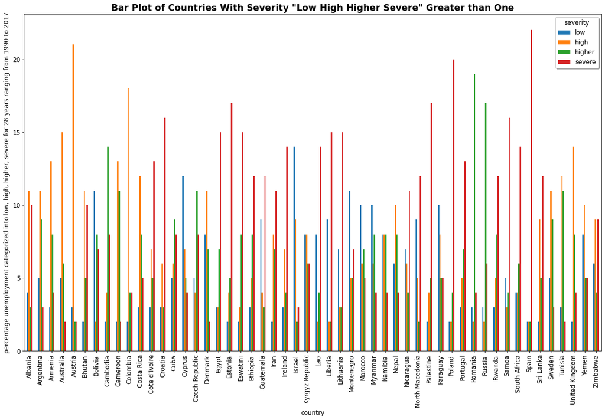

```python
df_crosstab_plot.plot.bar(x='country', y=['low', 'high', 'higher', 'severe'], figsize=(20, 12), label=['low', 'high', 'higher', 'severe'])
plt.xticks(fontsize='large')
plt.yticks(fontsize='large')
plt.title('Bar Plot of Countries With Severity "Low High Higher Severe" Greater than One', fontdict={'fontsize': 'xx-large', 'fontweight': 'bold'})
plt.xlabel('country', fontsize='large')
plt.ylabel("percentage unemployment categorized into low, high, higher, severe for 28 years ranging from 1990 to 2017", fontsize='large')
plt.legend(title='severity', title_fontsize='large', fontsize='large',loc='best',
          frameon=True, fancybox=True, shadow=True);
```

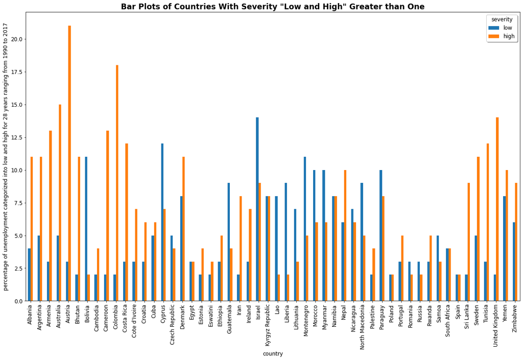

```python
df_crosstab_plot.plot.bar(x='country', y=['low', 'high'], figsize=(20, 12), label=['low', 'high'])
plt.xticks(fontsize='large')
plt.yticks(fontsize='large')
plt.title('Bar Plots of Countries With Severity "Low and High" Greater than One', fontdict={'fontsize': 'xx-large', 'fontweight': 'bold'})
plt.xlabel("country", fontsize='large')
plt.ylabel("percentage of unemployment categorized into low and high for 28 years ranging from 1990 to 2017", fontsize='large')
plt.legend(title='severity', title_fontsize='large', fontsize='large',loc='best',
          frameon=True, fancybox=True, shadow=True);
```

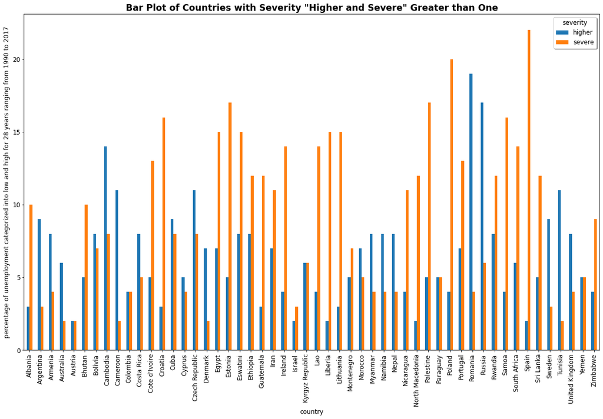

```python
df_crosstab_plot.plot.bar(x='country', y=['higher', 'severe'], figsize=(20, 12), label=['higher', 'severe'])
plt.xticks(fontsize='large')
plt.yticks(fontsize='large')
plt.title('Bar Plot of Countries with Severity "Higher and Severe" Greater than One', fontdict={'fontsize': 'xx-large', 'fontweight': 'bold'})
plt.xlabel("country", fontsize='large')
plt.ylabel("percentage of unemployment categorized into low and high for 28 years ranging from 1990 to 2017", fontsize='large')
plt.legend(title='severity', title_fontsize='large', fontsize='large',loc='best',
          frameon=True, fancybox=True, shadow=True);
```

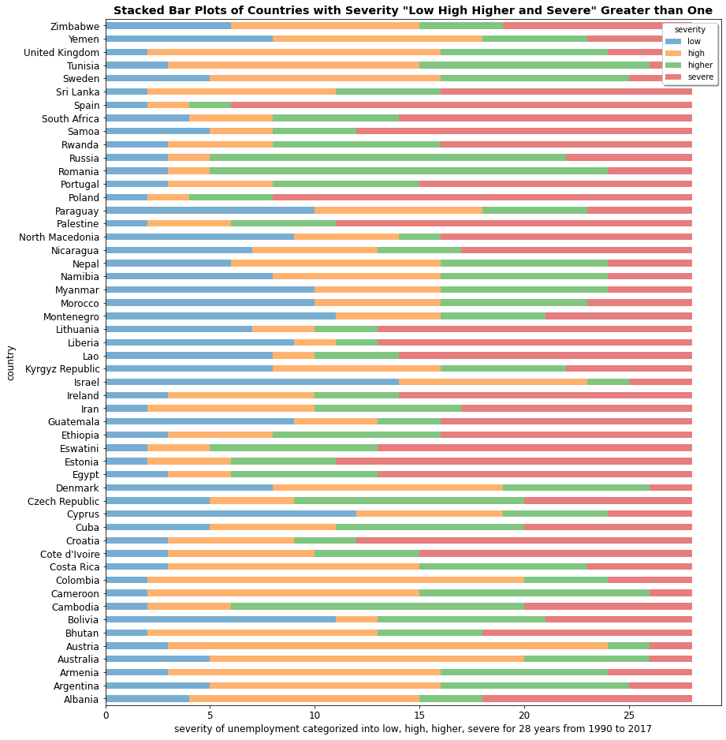

```python
stacked_barplot = df_crosstab_plot.plot.barh(x='country', y=['low', 'high', 'higher', 'severe'], figsize=(14, 16),
    stacked= True, alpha=0.6, label=['low', 'high', 'higher', 'severe'])
plt.title('Stacked Bar Plots of Countries with Severity "Low High Higher and Severe" Greater than One', fontdict={'fontsize': 'x-large', 'fontweight': 'bold'})
stacked_barplot.set_xlabel("severity of unemployment categorized into low, high, higher, severe for 28 years from 1990 to 2017", fontsize='large')
plt.ylabel("country", fontsize='large')
plt.xticks(fontsize='large')
plt.yticks(fontsize='large')
plt.legend(title='severity', title_fontsize='medium', fontsize='medium',loc='upper right',
           frameon=True, fancybox=True, shadow=True);
```

## Observations From Bar Plots and Stacked Bar Plots

- Plotting all the countries in bar plots with all severity categories makes the bar plots too clustered
- In stacked bar plot I could visualize all the severity levels
- There are 52 countries that has enountered or been through low, high, higher, & severe categories of unemployment
- The number of countries and categories will change based on methods to fill NaN and also based on methods followed to categorize

### Q4. Which country has higher long term unemployment percentage and which country has lower long term unemployment rate percentage?

```python
## To answer this question I work with the cleaned dataset df_clean, since it's sufficient to answer this question
```

```python
df_clean.describe()
```

|  | year | percent_unemployment |
| --- | --- | --- |
| count | 3416.00000 | 3416.000000 |
| mean | 2003.50000 | 1.901045 |
| std | 8.07893 | 1.573176 |
| min | 1990.00000 | 0.014200 |
| 25% | 1996.75000 | 0.875000 |
| 50% | 2003.50000 | 1.486250 |
| 75% | 2010.25000 | 2.476250 |
| max | 2017.00000 | 14.000000 |

```python
df_clean.query('percent_unemployment > 13')
```

|  | country | year | percent_unemployment |
| --- | --- | --- | --- |
| 2030 | North Macedonia | 2006 | 14.0 |
| 2152 | North Macedonia | 2007 | 14.0 |
| 2274 | North Macedonia | 2008 | 13.5 |

```python
df_clean.query('percent_unemployment < 0.015')
```

|  | country | year | percent_unemployment |
| --- | --- | --- | --- |
| 3257 | Philippines | 2016 | 0.0142 |
| 3379 | Philippines | 2017 | 0.0144 |

```python
df_clean.query('country == "Philippines"')
```

|  | country | year | percent_unemployment |
| --- | --- | --- | --- |
| 85 | Philippines | 1990 | 0.714571 |
| 207 | Philippines | 1991 | 0.717143 |
| 329 | Philippines | 1992 | 3.468571 |
| 451 | Philippines | 1993 | 3.574286 |
| 573 | Philippines | 1994 | 3.728571 |
| 695 | Philippines | 1995 | 3.354000 |
| 817 | Philippines | 1996 | 3.063714 |
| 939 | Philippines | 1997 | 3.026143 |
| 1061 | Philippines | 1998 | 2.719000 |
| 1183 | Philippines | 1999 | 3.032000 |
| 1305 | Philippines | 2000 | 4.380000 |
| 1427 | Philippines | 2001 | 0.100000 |
| 1549 | Philippines | 2002 | 3.444500 |
| 1671 | Philippines | 2003 | 0.077500 |
| 1793 | Philippines | 2004 | 0.076700 |
| 1915 | Philippines | 2005 | 0.057100 |
| 2037 | Philippines | 2006 | 0.058300 |
| 2159 | Philippines | 2007 | 0.039500 |
| 2281 | Philippines | 2008 | 0.042500 |
| 2403 | Philippines | 2009 | 0.040700 |
| 2525 | Philippines | 2010 | 0.027800 |
| 2647 | Philippines | 2011 | 0.026200 |
| 2769 | Philippines | 2012 | 0.026700 |
| 2891 | Philippines | 2013 | 0.023900 |
| 3013 | Philippines | 2014 | 0.018200 |
| 3135 | Philippines | 2015 | 1.597333 |
| 3257 | Philippines | 2016 | 0.014200 |
| 3379 | Philippines | 2017 | 0.014400 |

## Countries with higher and lower long term Unemployment Percentage

- North Macedonia is a country with higher long term unemployment percentage
- Philippines is a country with lower long term unemployment percentage
- Here is an [article](https://tradingeconomics.com/macedonia/long-term-unemployment-rate#:~:text=Long%20Term%20Unemployment%20Rate%20in%20Macedonia%20averaged%2022.70%20percent%20from,the%20first%20quarter%20of%202020.) on long term unemployment of North Macedonia
- Here is a wikipedia [article](https://en.wikipedia.org/wiki/Economy_of_the_Philippines) on economy of Phillippines
- Here is a Wall Street Journal [article](https://www.wsj.com/articles/long-term-unemployment-poses-rising-risk-to-the-economy-11601652449) on effects long term unemployment

### Q5. What is the trend of long term unemployment rate percentage of 5 highly economically developed countries?

## Finding Out Five Highly Economically Developed Countries

- I Filter out five highly economically developed countries
- I refer Wikipedia to filter out highly developed countries
- Here is the Wikipedia [article](https://en.wikipedia.org/wiki/Developed_country)
- Hong Kong or China is not available in the dataset
- As per the Wikipedia article, as of 2018 top 5 highly developed countries are Norway, Switzerland, Ireland, Germany, Hong Kong
- This is based on Human Development Index (HDI)
- The order of countries change based on parameter based on which the courtries are compared
- Since Hong Kong is not available in the Dataset I chose Australia, the next one as per the Wikipedia article
- Even though the dataset is only limited to 2017 I consider the Wikipedia article for filtering

```python
df_fiveeconomically_developed = df_clean[df_clean['country'].isin(["Norway", "Switzerland", "Ireland", "Germany", "Australia"])]
```

```python
# I filter out df_clean dataset and store that in df_fiveeconomically_developed dataframe
# I perform initial tests in the filtered dataset
```

```python
df_fiveeconomically_developed.info()
```

```
<class 'pandas.core.frame.DataFrame'>
Int64Index: 140 entries, 5 to 3398
Data columns (total 3 columns):
 #   Column                Non-Null Count  Dtype
---  ------                --------------  -----
 0   country               140 non-null    object
 1   year                  140 non-null    int64
 2   percent_unemployment  140 non-null    float64
dtypes: float64(1), int64(1), object(1)
memory usage: 4.4+ KB
```

```python
df_fiveeconomically_developed.nunique()
```

```
country                   5
year                     28
percent_unemployment    122
dtype: int64
```

```python
sum(df_fiveeconomically_developed.duplicated())
```

```
0
```

```python
df_fiveeconomically_developed.describe()
```

|  | year | percent_unemployment |
| --- | --- | --- |
| count | 140.000000 | 140.000000 |
| mean | 2003.500000 | 1.650233 |
| std | 8.106752 | 1.134756 |
| min | 1990.000000 | 0.284000 |
| 25% | 1996.750000 | 0.894000 |
| 50% | 2003.500000 | 1.240000 |
| 75% | 2010.250000 | 2.226786 |
| max | 2017.000000 | 5.410000 |

```python
df_fiveeconomically_developed['percent_unemployment'].describe()
```

```
count    140.000000
mean       1.650233
std        1.134756
min        0.284000
25%        0.894000
50%        1.240000
75%        2.226786
max        5.410000
Name: percent_unemployment, dtype: float64
```

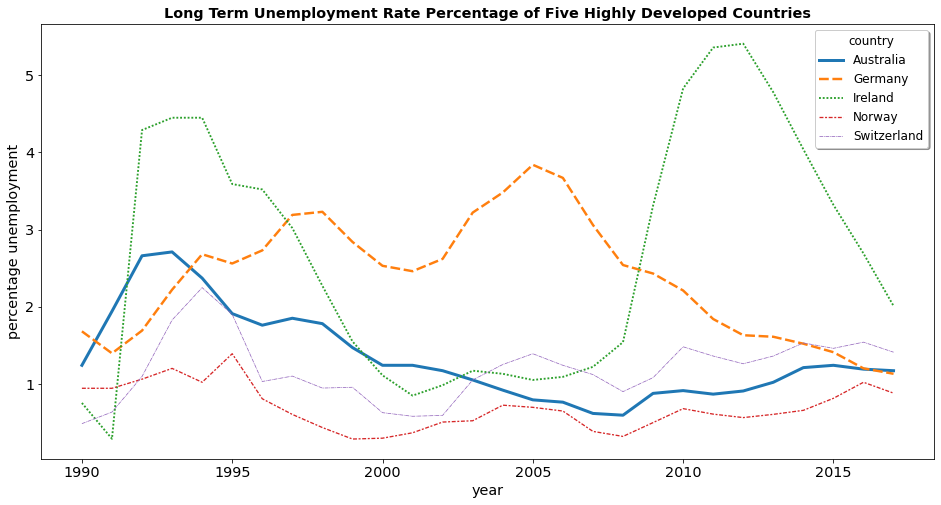

```python
plt.figure(figsize = (16, 8))
sb.lineplot(x = 'year', y='percent_unemployment', data=df_fiveeconomically_developed, hue='country', style='country',
            size='country')
plt.xticks(fontsize='x-large')
plt.yticks(fontsize='x-large')
plt.legend(title='country', title_fontsize='large', fontsize='large',loc='upper right',
          frameon=True, fancybox=True, shadow=True)
plt.title("Long Term Unemployment Rate Percentage of Five Highly Developed Countries", fontdict={'fontsize': 'x-large', 'fontweight': 'bold'})
plt.xlabel("year", fontsize='x-large')
plt.ylabel("percentage unemployment", fontsize='x-large');
```

## Observations After Comparing Five Economically Developed Countries Based on HDI

- Comparing long term unemployment percentage of economically developed countries based on HDI gives further insight into the dataset
- As per the article in the Wikipedia I expected Ireland to fall in the lower side
- But as per the Gapminder dataset Ireland has highest long term unemployment percentage of the five highly developed countries
- Most likely it may not be the best method to filter out economically developed countries based on HDI Index
- Overall, highly economically developed countries have lesser long term unemployment percentage than less developed countries

## Conclusions

### Limitations

- Some of the percent_unemployment in Philippines in the year was NaN. I replaced those values with linear interpolation
- Filling NaN with linear interpolation has resulted in long term unemployment percentage of Philippines in the year 2000 to be more than 4
- The analysis results depend heavily on the method used for filling NaN
- Further, the Gapminder data is only about registered long term unemployment percentage over the years 1990 - 2017

### What might be the reason for data insufficiency?

- Long term Unemployment percentage of highly economically developed countries are available to larger extent
- But for some countries long term unemployment percentage for only one year is available, for example, Zimbabwe
- Determining whether there is a bias in data or not is not the scope of analysis
- But in Gapminder it is clearly mentioned that it is the data of only registered long term unemployment percentage
- It is still only puzzling, I could not figure out why long term unemployment percentage for some countries are not at all available and only data for very less number of years is available for some countries

### Few more filtering

- In the following cells I just filter out and observe the NaN in some countries

```python
df_melt.query('country == "Philippines"')
```

|  | country | year | percent_unemployment |
| --- | --- | --- | --- |
| 85 | Philippines | 1990 | NaN |
| 207 | Philippines | 1991 | NaN |
| 329 | Philippines | 1992 | NaN |
| 451 | Philippines | 1993 | NaN |
| 573 | Philippines | 1994 | NaN |
| 695 | Philippines | 1995 | NaN |
| 817 | Philippines | 1996 | NaN |
| 939 | Philippines | 1997 | NaN |
| 1061 | Philippines | 1998 | NaN |
| 1183 | Philippines | 1999 | NaN |
| 1305 | Philippines | 2000 | NaN |
| 1427 | Philippines | 2001 | 0.1000 |
| 1549 | Philippines | 2002 | NaN |
| 1671 | Philippines | 2003 | 0.0775 |
| 1793 | Philippines | 2004 | 0.0767 |
| 1915 | Philippines | 2005 | 0.0571 |
| 2037 | Philippines | 2006 | 0.0583 |
| 2159 | Philippines | 2007 | 0.0395 |
| 2281 | Philippines | 2008 | 0.0425 |
| 2403 | Philippines | 2009 | 0.0407 |
| 2525 | Philippines | 2010 | 0.0278 |
| 2647 | Philippines | 2011 | 0.0262 |
| 2769 | Philippines | 2012 | 0.0267 |
| 2891 | Philippines | 2013 | 0.0239 |
| 3013 | Philippines | 2014 | 0.0182 |
| 3135 | Philippines | 2015 | NaN |
| 3257 | Philippines | 2016 | 0.0142 |
| 3379 | Philippines | 2017 | 0.0144 |

```python
df_melt.query('country == "Ireland"')
```

|  | country | year | percent_unemployment |
| --- | --- | --- | --- |
| 50 | Ireland | 1990 | NaN |
| 172 | Ireland | 1991 | NaN |
| 294 | Ireland | 1992 | 4.290 |
| 416 | Ireland | 1993 | 4.450 |
| 538 | Ireland | 1994 | 4.450 |
| 660 | Ireland | 1995 | 3.590 |
| 782 | Ireland | 1996 | 3.520 |
| 904 | Ireland | 1997 | 3.020 |
| 1026 | Ireland | 1998 | 2.270 |
| 1148 | Ireland | 1999 | 1.550 |
| 1270 | Ireland | 2000 | 1.110 |
| 1392 | Ireland | 2001 | 0.847 |
| 1514 | Ireland | 2002 | 0.982 |
| 1636 | Ireland | 2003 | 1.170 |
| 1758 | Ireland | 2004 | 1.130 |
| 1880 | Ireland | 2005 | 1.050 |
| 2002 | Ireland | 2006 | 1.090 |
| 2124 | Ireland | 2007 | 1.220 |
| 2246 | Ireland | 2008 | 1.540 |
| 2368 | Ireland | 2009 | 3.310 |
| 2490 | Ireland | 2010 | 4.830 |
| 2612 | Ireland | 2011 | 5.360 |
| 2734 | Ireland | 2012 | 5.410 |
| 2856 | Ireland | 2013 | 4.780 |
| 2978 | Ireland | 2014 | 4.040 |
| 3100 | Ireland | 2015 | 3.320 |
| 3222 | Ireland | 2016 | 2.690 |
| 3344 | Ireland | 2017 | 2.010 |

```python
df_melt.query('country == "Norway"')
```

|  | country | year | percent_unemployment |
| --- | --- | --- | --- |
| 79 | Norway | 1990 | 0.942 |
| 201 | Norway | 1991 | 0.942 |
| 323 | Norway | 1992 | 1.060 |
| 445 | Norway | 1993 | 1.200 |
| 567 | Norway | 1994 | 1.020 |
| 689 | Norway | 1995 | 1.390 |
| 811 | Norway | 1996 | 0.806 |
| 933 | Norway | 1997 | 0.603 |
| 1055 | Norway | 1998 | 0.433 |
| 1177 | Norway | 1999 | 0.284 |
| 1299 | Norway | 2000 | 0.295 |
| 1421 | Norway | 2001 | 0.365 |
| 1543 | Norway | 2002 | 0.504 |
| 1665 | Norway | 2003 | 0.521 |
| 1787 | Norway | 2004 | 0.723 |
| 1909 | Norway | 2005 | 0.695 |
| 2031 | Norway | 2006 | 0.647 |
| 2153 | Norway | 2007 | 0.383 |
| 2275 | Norway | 2008 | 0.318 |
| 2397 | Norway | 2009 | 0.497 |
| 2519 | Norway | 2010 | 0.678 |
| 2641 | Norway | 2011 | 0.607 |
| 2763 | Norway | 2012 | 0.562 |
| 2885 | Norway | 2013 | 0.604 |
| 3007 | Norway | 2014 | 0.656 |
| 3129 | Norway | 2015 | 0.812 |
| 3251 | Norway | 2016 | 1.020 |
| 3373 | Norway | 2017 | 0.879 |

```python
df_melt.query('country == "Switzerland"')
```

|  | country | year | percent_unemployment |
| --- | --- | --- | --- |
| 104 | Switzerland | 1990 | NaN |
| 226 | Switzerland | 1991 | NaN |
| 348 | Switzerland | 1992 | NaN |
| 470 | Switzerland | 1993 | NaN |
| 592 | Switzerland | 1994 | NaN |
| 714 | Switzerland | 1995 | NaN |
| 836 | Switzerland | 1996 | 1.030 |
| 958 | Switzerland | 1997 | 1.100 |
| 1080 | Switzerland | 1998 | 0.945 |
| 1202 | Switzerland | 1999 | 0.955 |
| 1324 | Switzerland | 2000 | 0.626 |
| 1446 | Switzerland | 2001 | 0.579 |
| 1568 | Switzerland | 2002 | 0.591 |
| 1690 | Switzerland | 2003 | 1.050 |
| 1812 | Switzerland | 2004 | 1.250 |
| 1934 | Switzerland | 2005 | 1.390 |
| 2056 | Switzerland | 2006 | 1.240 |
| 2178 | Switzerland | 2007 | 1.120 |
| 2300 | Switzerland | 2008 | 0.899 |
| 2422 | Switzerland | 2009 | 1.080 |
| 2544 | Switzerland | 2010 | 1.480 |
| 2666 | Switzerland | 2011 | 1.360 |
| 2788 | Switzerland | 2012 | 1.260 |
| 2910 | Switzerland | 2013 | 1.360 |
| 3032 | Switzerland | 2014 | 1.530 |
| 3154 | Switzerland | 2015 | 1.460 |
| 3276 | Switzerland | 2016 | 1.540 |
| 3398 | Switzerland | 2017 | 1.410 |

```python
df_melt.query('country == "Germany"')
```

|  | country | year | percent_unemployment |
| --- | --- | --- | --- |
| 41 | Germany | 1990 | NaN |
| 163 | Germany | 1991 | NaN |
| 285 | Germany | 1992 | 1.69 |
| 407 | Germany | 1993 | 2.22 |
| 529 | Germany | 1994 | 2.68 |
| 651 | Germany | 1995 | 2.56 |
| 773 | Germany | 1996 | 2.73 |
| 895 | Germany | 1997 | 3.19 |
| 1017 | Germany | 1998 | 3.23 |
| 1139 | Germany | 1999 | 2.84 |
| 1261 | Germany | 2000 | 2.53 |
| 1383 | Germany | 2001 | 2.46 |
| 1505 | Germany | 2002 | 2.62 |
| 1627 | Germany | 2003 | 3.22 |
| 1749 | Germany | 2004 | 3.48 |
| 1871 | Germany | 2005 | 3.84 |
| 1993 | Germany | 2006 | 3.67 |
| 2115 | Germany | 2007 | 3.06 |
| 2237 | Germany | 2008 | 2.54 |
| 2359 | Germany | 2009 | 2.43 |
| 2481 | Germany | 2010 | 2.21 |
| 2603 | Germany | 2011 | 1.84 |
| 2725 | Germany | 2012 | 1.63 |
| 2847 | Germany | 2013 | 1.61 |
| 2969 | Germany | 2014 | 1.52 |
| 3091 | Germany | 2015 | 1.41 |
| 3213 | Germany | 2016 | 1.20 |
| 3335 | Germany | 2017 | 1.13 |

```python
df_melt.query('country == "Australia"')
```

|  | country | year | percent_unemployment |
| --- | --- | --- | --- |
| 5 | Australia | 1990 | 1.240 |
| 127 | Australia | 1991 | 1.940 |
| 249 | Australia | 1992 | 2.660 |
| 371 | Australia | 1993 | 2.710 |
| 493 | Australia | 1994 | 2.370 |
| 615 | Australia | 1995 | 1.910 |
| 737 | Australia | 1996 | 1.760 |
| 859 | Australia | 1997 | 1.850 |
| 981 | Australia | 1998 | 1.780 |
| 1103 | Australia | 1999 | 1.470 |
| 1225 | Australia | 2000 | 1.240 |
| 1347 | Australia | 2001 | 1.240 |
| 1469 | Australia | 2002 | 1.170 |
| 1591 | Australia | 2003 | 1.050 |
| 1713 | Australia | 2004 | 0.918 |
| 1835 | Australia | 2005 | 0.792 |
| 1957 | Australia | 2006 | 0.762 |
| 2079 | Australia | 2007 | 0.616 |
| 2201 | Australia | 2008 | 0.593 |
| 2323 | Australia | 2009 | 0.876 |
| 2445 | Australia | 2010 | 0.912 |
| 2567 | Australia | 2011 | 0.866 |
| 2689 | Australia | 2012 | 0.907 |
| 2811 | Australia | 2013 | 1.020 |
| 2933 | Australia | 2014 | 1.210 |
| 3055 | Australia | 2015 | 1.240 |
| 3177 | Australia | 2016 | 1.190 |
| 3299 | Australia | 2017 | 1.170 |

```python
df_melt.query('country == "Zimbabwe"')
```

|  | country | year | percent_unemployment |
| --- | --- | --- | --- |
| 121 | Zimbabwe | 1990 | NaN |
| 243 | Zimbabwe | 1991 | NaN |
| 365 | Zimbabwe | 1992 | NaN |
| 487 | Zimbabwe | 1993 | NaN |
| 609 | Zimbabwe | 1994 | NaN |
| 731 | Zimbabwe | 1995 | NaN |
| 853 | Zimbabwe | 1996 | NaN |
| 975 | Zimbabwe | 1997 | NaN |
| 1097 | Zimbabwe | 1998 | NaN |
| 1219 | Zimbabwe | 1999 | NaN |
| 1341 | Zimbabwe | 2000 | NaN |
| 1463 | Zimbabwe | 2001 | NaN |
| 1585 | Zimbabwe | 2002 | NaN |
| 1707 | Zimbabwe | 2003 | NaN |
| 1829 | Zimbabwe | 2004 | NaN |
| 1951 | Zimbabwe | 2005 | NaN |
| 2073 | Zimbabwe | 2006 | NaN |
| 2195 | Zimbabwe | 2007 | NaN |
| 2317 | Zimbabwe | 2008 | NaN |
| 2439 | Zimbabwe | 2009 | NaN |
| 2561 | Zimbabwe | 2010 | NaN |
| 2683 | Zimbabwe | 2011 | NaN |
| 2805 | Zimbabwe | 2012 | NaN |
| 2927 | Zimbabwe | 2013 | NaN |
| 3049 | Zimbabwe | 2014 | 2.42 |
| 3171 | Zimbabwe | 2015 | NaN |
| 3293 | Zimbabwe | 2016 | NaN |
| 3415 | Zimbabwe | 2017 | NaN |

## Concluding Remarks

- Thanks to Udacity
- I literally started with nothing
- The course structure is awesome
- The instructors have literally empowered me to explore on my own
- Especially the final statement in the Rubric to use Numpy and Pandas than what's covered in the course is motivating
- I bought the second edition of Python for Data Analysis written by Wes McKinney
- I also bought another book 'Pandas for Everyone' written by Daniel Y Chen
- I mean I started exploring on my own and I used these books extensively
- I chose the dataset on long term unemployment it is because I am unemployed for a long time
- But the great thing is that I thought that I couldn't program at all, and then I learned some Python
- But I thought I need to know more of Python to become a Data Analyst
- But I was proved wrong
- I know there is a long way to go
- Now I am sure that I will make it
- Thanks again to Udacity
- I am keen on gaining more knowledge and complete this course and then learn machine learning

Thanks again, Sakthivel. T